# Effects of Trip Characteristics on Trip Duration

## Distribution of Duration

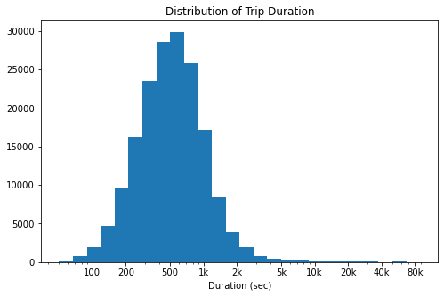

## Trip Frequency by Hours of the Day (Start time)

In the case of hour of the day, the highest number of rides were between 8am and 9am in the morning and also 5pm-6pm in the evening. Least rides were recorded at the early hours of the day

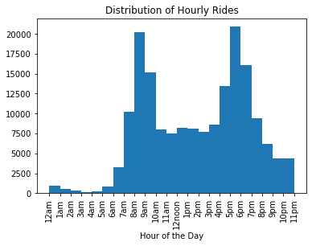

## Frequency by days of the week

In the case of days of the week, the highest number of rides were on Thursday, followed by Tuesdays. Least number of rides were recorded on weekends

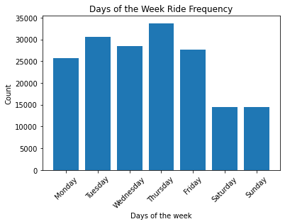

## Distribution for Gender, User Type and Bike Share

The number of trips made by subscribers is far greater than that made by customers. Also more men take bike rides than women and also few bike are shared for all trip.

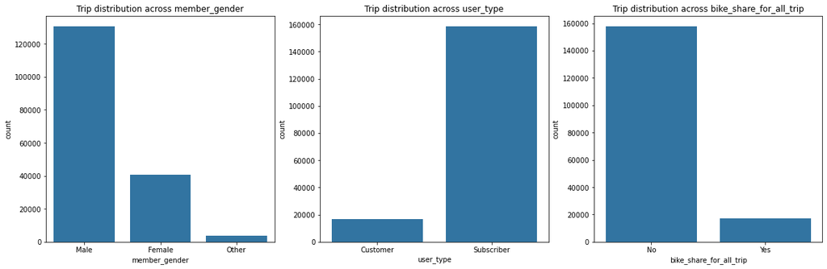

## Average Trip Duration by Category

The mean trip duration is highest among others, followed by Female and then Male. Customers have higher mean trip duration time compared with Subscribers.

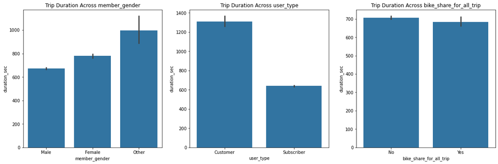

## Average Trip Duration for each hour of the day

Though the distribution of duration for each hour appears to be uniform, the mean duration is greatest at 3am in the morning.

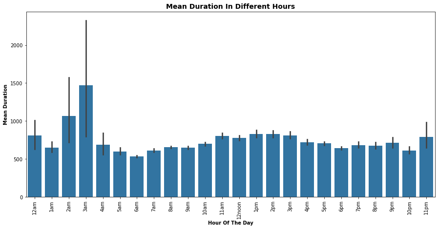

## Average Trip Duration for each day of the week

Though the distribution of duration for the days appears to be uniform and the total number of ride is least at weekends, the mean duration is highest in the weekend.

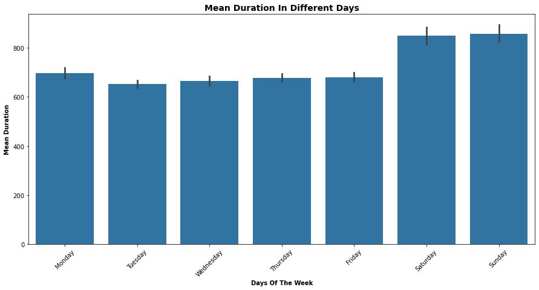

## ## User Categories vs Trip Fequency

For all days of the week, the number of male bike riders is highest followed by Female and others. Also, all days of the week sees higher number of subscribers than customers and higher number of riders that did not share their ride for all trip.

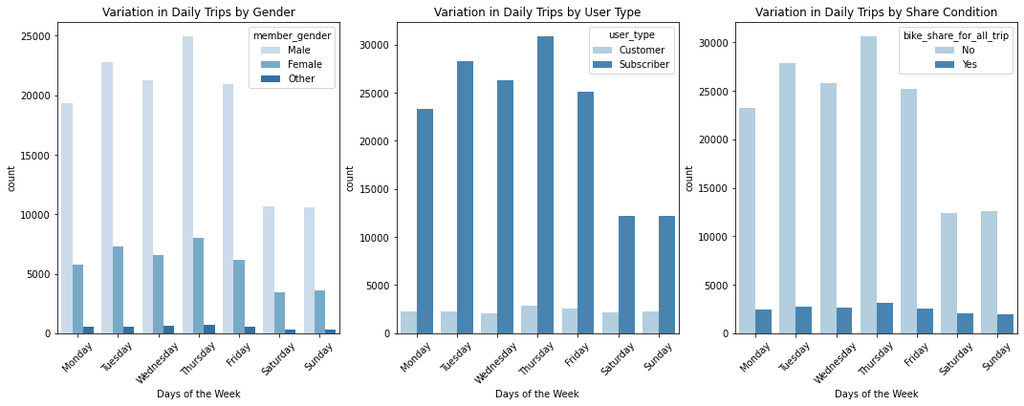

## Duration by User Type and Gender for Each Days of the Week

For the gender and member type categories, the mean duration is highest on weekends. For each days of the week, customers have the highest mean duration compared to subscribers and also riders that have their gender registered as "others" have the highest mean trip duration followed by female then male.

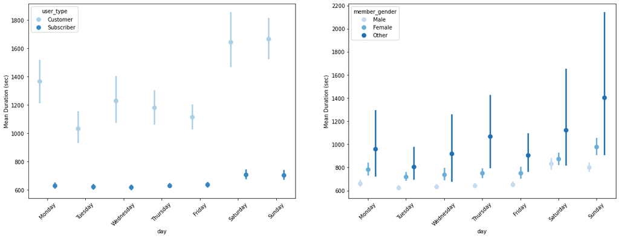